# 2019_05_02_foldchange_stabilityanalysis_control

Toni Beltran

02/05/2019

This code is an alternative mode of predicting epimutation duration from the normalized 22G count data - rather than binarizing the data, it considers the continuous range of the 22G count data to estimate duration.

First, each data point xij (counts for gene i at generation j) is converted to the log2 fold change of xij relative to the mean of counts for gene i across generations; log2(xij+10)-log2(mean gene i +10). In order to stabilize fold changes for the parts of the lineage with extremely low counts, 10 pseudocpms are added - this prevents selecting small differences in 22Gs from being detected as epimutation events.

Then a function scans the log2 transformed data looking for fold changes of at least 2 between consecutive data points. Each of these events is stored along with the rest of the data points following the change up to the rest of the lineage. Then a scanning function is applied to each of these events, in order to determine for how many generations the fold change remains 2 or larger than 2 relative to the pre-epimutation generation. Basically the function just loops along generations until the fold change calculated is not 2 or more, then breaks and stores the number of generations that it looped for. If it reaches the end of the lineage, the duration is stored and the event is labelled as incomplete.

```r
library(gplots)
library(RColorBrewer)
library(ggplot2)
library(depmixS4)
library(DESeq2)
setwd("/Users/ab6415/Documents/Work_laptop_stuff/Bioinformatics/Analysis/Beltran_et_al_2020_NEE/05_Figure3/")

ttg_DEseqnorm<-read.table("../02_Normalised_counts/22G_DEseqnorm_counts_averaged.txt")
ttg_MAplot_data<-read.table("../03_04_Figures1-2/MAplot_filtering_22Gs_genbygen_p1e-2.txt",header=TRUE)
ttg_MAplot_data<-ttg_MAplot_data[which(ttg_MAplot_data$padj<1e-4),]

summary_stats_A<-data.frame(mean=apply(ttg_DEseqnorm[,1:12],MARGIN=1,FUN = mean),
                            min=apply(ttg_DEseqnorm[,1:12],MARGIN=1,FUN = min))

summary_stats_B<-data.frame(mean=apply(ttg_DEseqnorm[,13:24],MARGIN=1,FUN = mean),
                            min=apply(ttg_DEseqnorm[,13:24],MARGIN=1,FUN = min))

summary_stats_AB<-data.frame(mean=apply(ttg_DEseqnorm[,1:24],MARGIN = 1,FUN=mean),
                             min=apply(ttg_DEseqnorm[,1:24],MARGIN = 1,FUN=min))
```

```r
#DEseq to identify genes contributing to batch variation (early vs late, plus B1-B4 samples), these will be ignored in downstream analysis

ttg_A_rawcounts<-read.table("../01_Raw_counts/RAW_22G_COUNTS/22G_RAW_COUNTS_lineageA.txt")
ttg_B_rawcounts<-read.table("../01_Raw_counts/RAW_22G_COUNTS/22G_RAW_COUNTS_lineageB.txt")
ttg_AB_rawcounts<-merge(ttg_A_rawcounts,ttg_B_rawcounts,by=0); rownames(ttg_AB_rawcounts)<-ttg_AB_rawcounts$Row.names; ttg_AB_rawcounts$Row.names<-NULL

cds<-DESeqDataSetFromMatrix(countData = ttg_AB_rawcounts,
                            colData = data.frame(line=colnames(ttg_AB_rawcounts),condition=as.factor(rep(c(rep(1,7),rep(2,5)),2))),
                            design= ~condition)
dds<-DESeq(cds)
```

```
## -- replacing outliers and refitting for 21 genes
## -- DESeq argument 'minReplicatesForReplace' = 7
## -- original counts are preserved in counts(dds)
```

```r
res<-results(dds)
res<-res[order(res$padj,decreasing = FALSE),]


removegenes_lastfive<-rownames(res[which(res$padj<0.2 & abs(res$log2FoldChange)>1),])


cds<-DESeqDataSetFromMatrix(countData = ttg_AB_rawcounts,
                            colData = data.frame(line=colnames(ttg_AB_rawcounts),condition=as.factor(c(rep(1,12),2,rep(1,3),2,rep(1,7)))),
                            design= ~condition)
dds<-DESeq(cds)
```

```
## -- replacing outliers and refitting for 41 genes
## -- DESeq argument 'minReplicatesForReplace' = 7
## -- original counts are preserved in counts(dds)
```

```r
res<-results(dds)
res<-res[order(res$padj,decreasing = FALSE),]

removegenes_b1_b5<-rownames(res[which(res$padj<0.2 & abs(res$log2FoldChange)>1),])

removegenes<-union(removegenes_lastfive,removegenes_b1_b5)
length(removegenes)
```

```
## [1] 2121
```

```r
epimutable_genes_genbygen<-ttg_MAplot_data$ID[-which(ttg_MAplot_data$ID %in% removegenes)]
length(unique(epimutable_genes_genbygen))
```

```
## [1] 145
```

```r
ttg_DEseqnorm_epimutable_genes<-ttg_DEseqnorm[which(rownames(ttg_DEseqnorm) %in% epimutable_genes_genbygen),]
nrow(ttg_DEseqnorm_epimutable_genes)
```

```
## [1] 145
```

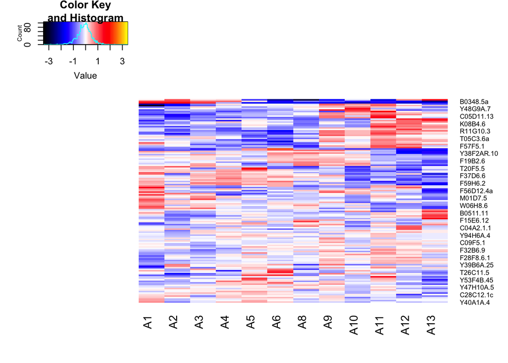

```r
normalise_log2fcmean<-function(df,normcount_thr,stats_df){
  df<-df[which(rownames(df) %in% rownames(stats_df[which(stats_df$mean>normcount_thr),])),]
  stats_df<-stats_df[rownames(df),]
  norm_df<-sweep(log2(df+10), MARGIN = 1, log2(stats_df$mean+10))
  return(norm_df)
}


logged_epimutable_genes_A<-normalise_log2fcmean(ttg_DEseqnorm_epimutable_genes[,1:12],10,summary_stats_A)
logged_epimutable_genes_B<-normalise_log2fcmean(ttg_DEseqnorm_epimutable_genes[,13:24],10,summary_stats_B)

heatmap.2(as.matrix(logged_epimutable_genes_A),col = colorRampPalette(c("black","blue","white","red","yellow"))(100),Colv=FALSE,trace="none",dendrogram = "none")
```

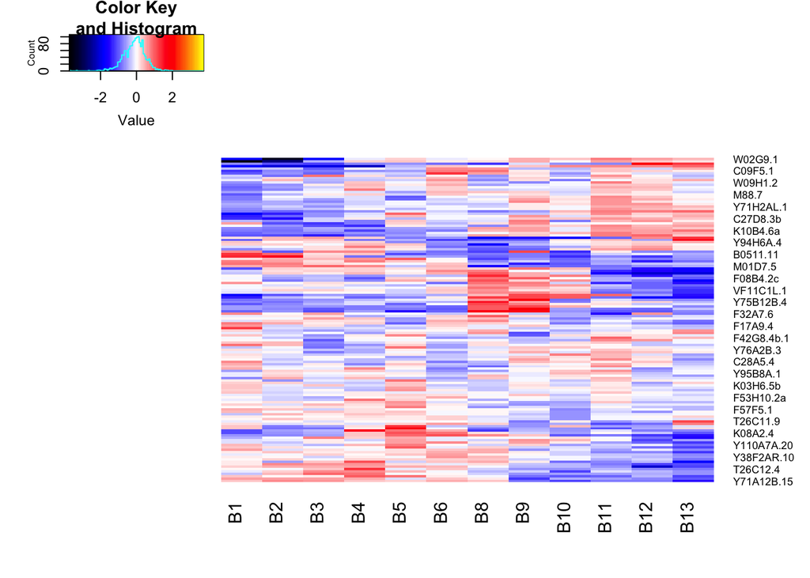

```r
heatmap.2(as.matrix(logged_epimutable_genes_B),col = colorRampPalette(c("black","blue","white","red","yellow"))(100),Colv=FALSE,trace="none",dendrogram = "none")
```

```r
logged_epimutable_genes_A_diff<-t(apply(logged_epimutable_genes_A,MARGIN = 1,FUN = diff))
logged_epimutable_genes_B_diff<-t(apply(logged_epimutable_genes_B,MARGIN = 1,FUN = diff))

#number of transitions with 2-fold change in small RNA levels between consecutive generations
length(which(abs(logged_epimutable_genes_A_diff)>=1,arr.ind = TRUE)[,"row"])
```

```
## [1] 137
```

```r
table(which(abs(logged_epimutable_genes_A_diff)>=1,arr.ind = TRUE)[,"col"])
```

```
##
##  1  2  3  4  5  6  7  8  9 10 11
## 16  6  6 10  8 14 16 12 19 16 14
```

```r
length(which(abs(logged_epimutable_genes_B_diff)>=1,arr.ind = TRUE)[,"row"])
```

```
## [1] 125
```

```r
table(which(abs(logged_epimutable_genes_B_diff)>=1,arr.ind = TRUE)[,"col"])
```

```
##
##  1  2  3  4  5  6  7  8  9 10 11
## 10  9  7 19 12 17 10 13 14  7  7
```

```r
#number of transitions with 4-fold change in small RNA levels between consecutive generations
length(which(abs(logged_epimutable_genes_A_diff)>=1.5,arr.ind = TRUE)[,"row"])
```

```
## [1] 38
```

```r
table(which(abs(logged_epimutable_genes_A_diff)>=1.5,arr.ind = TRUE)[,"col"])
```

```
##
##  1  3  4  5  6  7  8  9 10 11
##  5  1  2  3  6  4  2  8  4  3
```

```r
length(which(abs(logged_epimutable_genes_B_diff)>=1.5,arr.ind = TRUE)[,"row"])
```

```
## [1] 39
```

```r
table(which(abs(logged_epimutable_genes_B_diff)>=1.5,arr.ind = TRUE)[,"col"])
```

```
##
##  1  2  3  4  5  6  7  8  9 10 11
##  3  4  2  2  3  8  2  5  3  4  3
```

```r
row_stability_fcthr<-function(row){
  row<-row[!is.na(row)]
  first_fc<-row[2]-row[1]
  if (first_fc<(-1)){down=TRUE
  } else if (first_fc>1){down=FALSE
  }
  duration<-0
  for (i in seq(2,length(row))){
    if (down==TRUE){
      if (row[i]-row[1]<1){
        duration<-duration+1
      }else{
        break
      }}
    if (down==FALSE){
      if (row[i]-row[1]>1){
        duration<-duration+1
      }else{
        i<-(i-1)
        break
      }}
  }
  if (i==length(row)){
    complete<-FALSE}
  else{complete<-TRUE}

  if (down==TRUE){
    upordown=1
  }
  if(down==FALSE){
    upordown=2
  }

  return(c(duration,complete,upordown,13-length(row)))
}
```

```r
#linA
A_epimuts_log2_1<-which(abs(logged_epimutable_genes_A_diff)>=1,arr.ind = TRUE)
A_epimut_traces_log2_1<-matrix(NA,nrow = nrow(A_epimuts_log2_1),ncol=12); rownames(A_epimut_traces_log2_1)<-rownames(A_epimuts_log2_1)
for (row in seq(nrow(A_epimuts_log2_1))){
  r<-A_epimuts_log2_1[row,"row"]
  c<-A_epimuts_log2_1[row,"col"]

  trace<-as.numeric(logged_epimutable_genes_A[r,c:12])
  A_epimut_traces_log2_1[row,1:length(trace)]<-trace
}

nrow(A_epimut_traces_log2_1)
```

```
## [1] 137
```

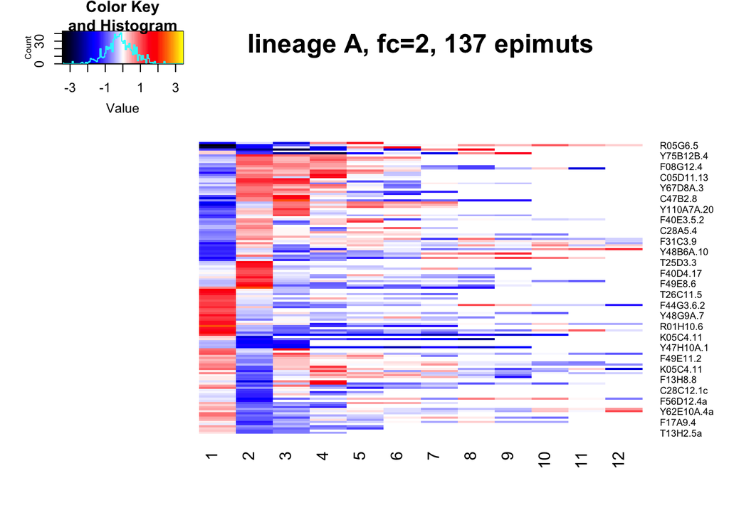

```r
heatmap.2(as.matrix(A_epimut_traces_log2_1),col = colorRampPalette(c("black","blue","white","red","yellow"))(100),Colv=FALSE,trace="none",dendrogram = "none",na.color = "white",main="lineage A, fc=2, 137 epimuts")
```

```r
epimuts_duration_fc2_A<-data.frame(t(apply(A_epimut_traces_log2_1,MARGIN = 1,FUN=row_stability_fcthr)))
colnames(epimuts_duration_fc2_A)<-c("duration","completeness","up_or_down","stgen")
epimuts_duration_fc2_A$ID<-rownames(A_epimut_traces_log2_1)

epimuts_duration_fc2_A<-epimuts_duration_fc2_A[,c("ID", "up_or_down", "duration", "completeness", "stgen")]


#account for missing gen7 data point
epimuts_duration_fc2_A$stgen_corrected<-epimuts_duration_fc2_A$stgen
epimuts_duration_fc2_A$duration_corrected<-epimuts_duration_fc2_A$duration
for (i in seq(nrow(epimuts_duration_fc2_A))){
  if (epimuts_duration_fc2_A[i,"stgen"]>6){
  epimuts_duration_fc2_A[i,"stgen_corrected"]<-epimuts_duration_fc2_A[i,"stgen_corrected"]+1
  }
  if ((epimuts_duration_fc2_A[i,"stgen"]+epimuts_duration_fc2_A[i,"duration"])>6 & epimuts_duration_fc2_A[i,"stgen"]<7){
  epimuts_duration_fc2_A[i,"duration_corrected"]<-epimuts_duration_fc2_A[i,"duration_corrected"]+1
  }
}

epimuts_duration_fc2_A$duration<-epimuts_duration_fc2_A$duration_corrected
epimuts_duration_fc2_A$stgen<-epimuts_duration_fc2_A$stgen_corrected
epimuts_duration_fc2_A$stgen_corrected<-NULL
epimuts_duration_fc2_A$duration_corrected<-NULL


table(epimuts_duration_fc2_A$complete)
```

```
##
##  0  1
## 85 52
```

```r
table(epimuts_duration_fc2_A$duration)
```

```
##
##  1  2  3  4  5  6  7  8  9 10 11 12
## 48 26 10 10  4  2 12  4  3  5  2 11
```

```r
table(epimuts_duration_fc2_A[which(epimuts_duration_fc2_A$complete==0),"duration"])
```

```
##
##  1  2  3  4  5  7  8  9 10 11 12
## 14 15  8  8  4 12  4  3  5  1 11
```

```r
table(epimuts_duration_fc2_A[which(epimuts_duration_fc2_A$complete==1),"duration"])
```

```
##
##  1  2  3  4  6 11
## 34 11  2  2  2  1
```

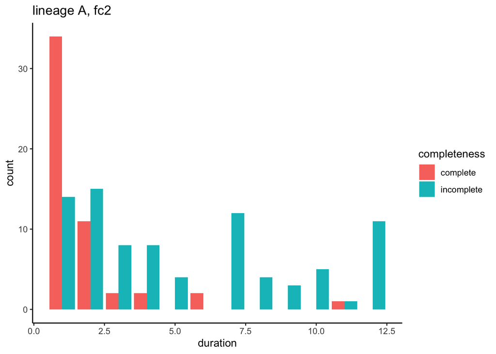

```r
A_data_for_barplot<-data.frame(duration=rep(seq(1,12),2),
                               count=c(
                                 table(factor(epimuts_duration_fc2_A[which(epimuts_duration_fc2_A$complete==1),"duration"],levels=c(1:12))),
                                 table(factor(epimuts_duration_fc2_A[which(epimuts_duration_fc2_A$complete==0),"duration"],levels=c(1:12)))),
                               completeness=c(rep("complete",12),rep("incomplete",12)))

# Grouped
ggplot(A_data_for_barplot, aes(fill=completeness, y=count, x=duration)) +
    geom_bar(position="dodge", stat="identity") + ggtitle("lineage A, fc2")+theme_classic()
```

```r
ggsave("logfc_duration_barplot_linA.pdf",dpi="retina")
#linB
B_epimuts_log2_1<-which(abs(logged_epimutable_genes_B_diff)>=1,arr.ind = TRUE)
B_epimut_traces_log2_1<-matrix(NA,nrow = nrow(B_epimuts_log2_1),ncol=12); rownames(B_epimut_traces_log2_1)<-rownames(B_epimuts_log2_1)
for (row in seq(nrow(B_epimuts_log2_1))){
  r<-B_epimuts_log2_1[row,"row"]
  c<-B_epimuts_log2_1[row,"col"]

  trace<-as.numeric(logged_epimutable_genes_B[r,c:12])
  B_epimut_traces_log2_1[row,1:length(trace)]<-trace
}

nrow(B_epimut_traces_log2_1)
```

```
## [1] 125
```

[figure not shown]

```r
heatmap.2(as.matrix(B_epimut_traces_log2_1),col = colorRampPalette(c("black","blue","white","red","yellow"))(100),Colv=FALSE,trace="none",dendrogram = "none",na.color = "white",main="lineage B, fc=2, 137 epimuts")
```

```r
epimuts_duration_fc2_B<-data.frame(t(apply(B_epimut_traces_log2_1,MARGIN = 1,FUN=row_stability_fcthr)))
colnames(epimuts_duration_fc2_B)<-c("duration","completeness","up_or_down","stgen")
epimuts_duration_fc2_B$ID<-rownames(B_epimut_traces_log2_1)

epimuts_duration_fc2_B<-epimuts_duration_fc2_B[,c("ID", "up_or_down", "duration", "completeness", "stgen")]

#account for missing gen7 data point
epimuts_duration_fc2_B$stgen_corrected<-epimuts_duration_fc2_B$stgen
epimuts_duration_fc2_B$duration_corrected<-epimuts_duration_fc2_B$duration
for (i in seq(nrow(epimuts_duration_fc2_B))){
  if (epimuts_duration_fc2_B[i,"stgen"]>6){
  epimuts_duration_fc2_B[i,"stgen_corrected"]<-epimuts_duration_fc2_B[i,"stgen_corrected"]+1
  }
  if ((epimuts_duration_fc2_B[i,"stgen"]+epimuts_duration_fc2_B[i,"duration"])>6 & epimuts_duration_fc2_B[i,"stgen"]<7){
  epimuts_duration_fc2_B[i,"duration_corrected"]<-epimuts_duration_fc2_B[i,"duration_corrected"]+1
  }
}

epimuts_duration_fc2_B$duration<-epimuts_duration_fc2_B$duration_corrected
epimuts_duration_fc2_B$stgen<-epimuts_duration_fc2_B$stgen_corrected
epimuts_duration_fc2_B$stgen_corrected<-NULL
epimuts_duration_fc2_B$duration_corrected<-NULL


table(epimuts_duration_fc2_B$completeness)
```

```
##
##  0  1
## 73 52
```

```r
table(epimuts_duration_fc2_B$duration)
```

```
##
##  1  2  3  4  5  6  7  8  9 10 11 12
## 31 20 17 11  8  1  5 10  8  2  7  5
```

```r
table(epimuts_duration_fc2_B[which(epimuts_duration_fc2_B$completeness==0),"duration"])
```

```
##
##  1  2  3  4  5  7  8  9 10 11 12
##  7  6  8 10  6  5 10  7  2  7  5
```

```r
table(epimuts_duration_fc2_B[which(epimuts_duration_fc2_B$completeness==1),"duration"])
```

```
##
##  1  2  3  4  5  6  9
## 24 14  9  1  2  1  1
```

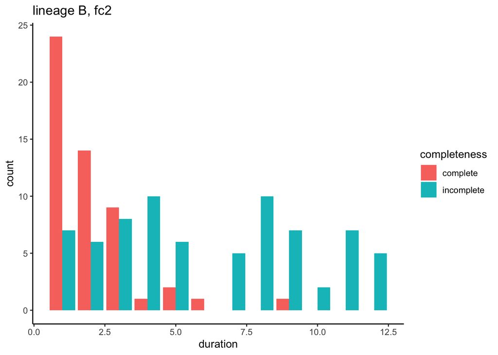

```r
B_data_for_barplot<-data.frame(duration=rep(seq(1,12),2),
                               count=c(
                                 table(factor(epimuts_duration_fc2_B[which(epimuts_duration_fc2_B$completeness==1),"duration"],levels=c(1:12))),
                                 table(factor(epimuts_duration_fc2_B[which(epimuts_duration_fc2_B$completeness==0),"duration"],levels=c(1:12)))),
                               completeness=c(rep("complete",12),rep("incomplete",12)))

# Grouped
ggplot(B_data_for_barplot, aes(fill=completeness, y=count, x=duration)) +
    geom_bar(position="dodge", stat="identity") + ggtitle("lineage B, fc2")+theme_classic()
```

```r
ggsave("logfc_duration_barplot_linB.pdf",dpi="retina")
#both lineages

epimuts_duration_fc2_A$lineage<-rep("A",nrow(epimuts_duration_fc2_A))
epimuts_duration_fc2_B$lineage<-rep("B",nrow(epimuts_duration_fc2_B))
epimuts_duration_fc2_both<-rbind(epimuts_duration_fc2_A,epimuts_duration_fc2_B)

table(epimuts_duration_fc2_both$complete)
```

```
##
##   0   1
## 158 104
```

```r
table(epimuts_duration_fc2_both$duration)
```

```
##
##  1  2  3  4  5  6  7  8  9 10 11 12
## 79 46 27 21 12  3 17 14 11  7  9 16
```

```r
table(epimuts_duration_fc2_both[which(epimuts_duration_fc2_both$complete==0),"duration"])
```

```
##
##  1  2  3  4  5  7  8  9 10 11 12
## 21 21 16 18 10 17 14 10  7  8 16
```

```r
table(epimuts_duration_fc2_both[which(epimuts_duration_fc2_both$complete==1),"duration"])
```

```
##
##  1  2  3  4  5  6  9 11
## 58 25 11  3  2  3  1  1
```

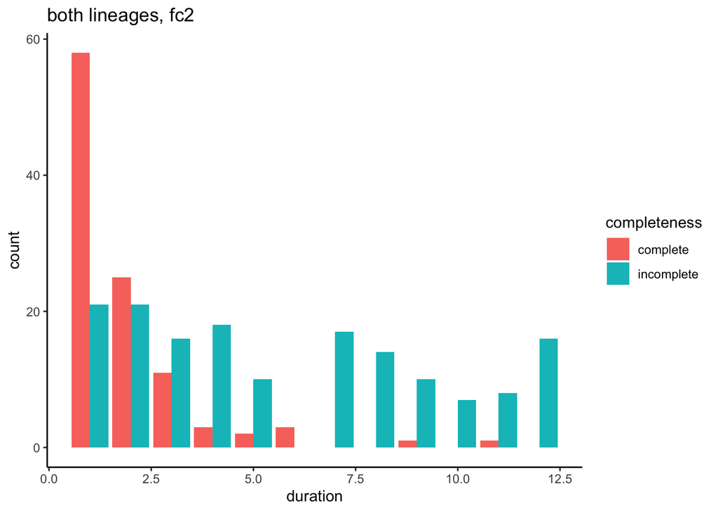

```r
both_data_for_barplot<-data.frame(duration=rep(seq(1,12),2),
                               count=c(table(factor(epimuts_duration_fc2_both[which(epimuts_duration_fc2_both$complete==1),"duration"],levels=c(1:12))),
                                       table(factor(epimuts_duration_fc2_both[which(epimuts_duration_fc2_both$complete==0),"duration"],levels=c(1:12)))),
                               completeness=c(rep("complete",12),rep("incomplete",12)))

# Grouped
ggplot(both_data_for_barplot, aes(fill=completeness, y=count, x=duration)) +
    geom_bar(position="dodge", stat="identity") + ggtitle("both lineages, fc2")+theme_classic()
```

```r
ggsave("logfc_duration_barplot_both_lins.pdf",dpi="retina")
write.table(epimuts_duration_fc2_both,file="epimutation_duration_logfc_bothlineages.txt")
```